# Exploring Species-Specific Traits with Binary Logistic Regression

Two Species of Palmetto Trees Walk Into an .rmd file

Caitie Reza  
01-20-2021

### Summary

This report utilizes data from the Archbold Biological Station in South-Central Florida (see citation below) to explore the phenology and assess the classification of two plant species of Palmetto trees: *Serenoa repens* and *Sabal etonia*. Here, we use binary logistic regression to analyze the relationship between the species and an array of dependent variables.

###### Data: Abrahamson, W.G. 2019. Survival, growth and biomass estimates of two dominant palmetto species of south-central Florida from 1981 - 2017, ongoing at 5-year intervals ver 1. Environmental Data Initiative.

```r
# 1. Read in Data
palmetto <- read_csv("palmetto.csv",
  col_types = cols(.default = "c")) %>%  #convert all to character
    mutate(height = as.numeric(height)) %>% # convert our explanatory variables to numeric
  mutate(length = as.numeric(length)) %>%
  mutate(width = as.numeric(width)) %>%
  mutate(green_lvs = as.numeric(green_lvs))
```

#### **Figures 1-3**: Visualizing Phenotypic Differences Between Palmetto Species

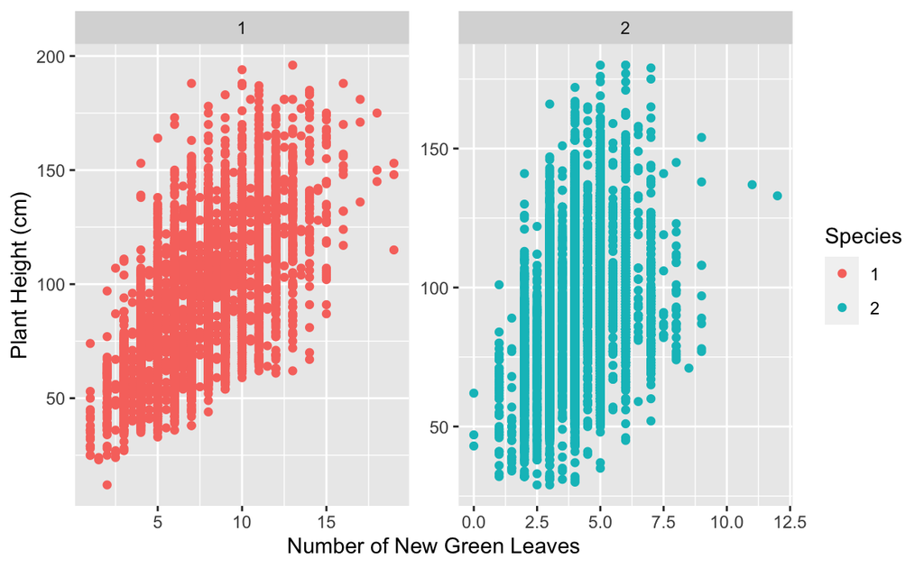

```r
#  Visualize relationships (or lack thereof) between my predictor variables to see if I spot any patterns

ggplot(data = palmetto, aes(x = green_lvs, y = height)) +
         geom_point(aes(color = species)) +
         facet_wrap(~species, scales = "free") +
  labs(x = "Number of New Green Leaves", y = "Plant Height (cm)",
       color = "Species")
```

**Figure 1.** shows the relationship between green leaf counts and plant height (cm) in 2 unidentified species of palmetto tree. Note the different scale between x axes (number of green leaves) and y axes (plant height).

- Both species exhibit a relatively positive relationship between green leaf counts and plant height.

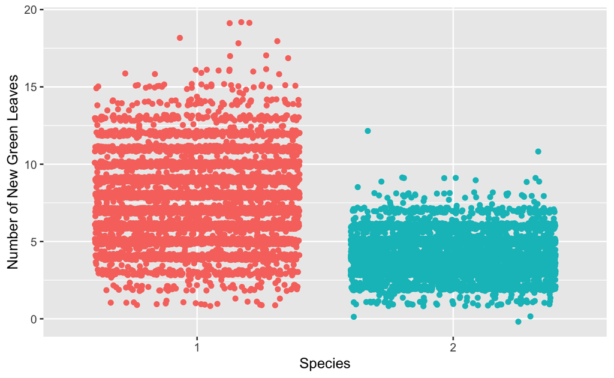

```r
ggplot(data = palmetto, aes(x = species, y = green_lvs, na.rm = TRUE)) +
  geom_jitter(aes(color = species)) +
  labs(x = "Species", y = "Number of New Green Leaves",
       color = "Species") +
  theme(legend.position = "none")
```

**Figure 2.** demonstrates the number of green leaves on Palmetto plants of Species 1 and 2.

- Based on the count data, Species 1 plants tend to have more new, green leaves as compared to Species 2.

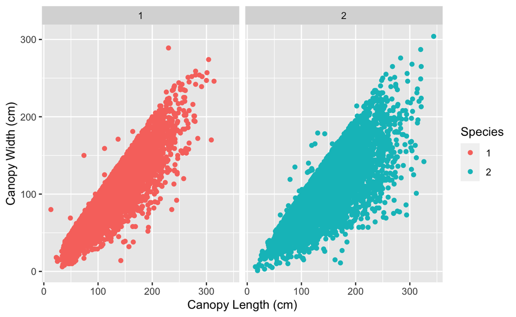

```r
ggplot(data = palmetto, aes(x = length, y = width)) +
  geom_point(aes(color = species)) +
  facet_wrap(~species) +
  labs(x= "Canopy Length (cm)", y = "Canopy Width (cm)",
       color = "Species")
```

**Figure 3.** shows the relationship between canopy length (cm) and canopy width (cm) measured for both Palmetto species.

- At first glance, there seems to be a positive correlation between canopy length and canopy width in both species.

### Binary Logistic Regression Model

```r
# Binary Logistic Regression

# Make subset with just our predictor + explanatory variables

palm_sub <- palmetto %>%
  select(species, height:green_lvs) %>%
  mutate(species = as.factor(species)) # make species a factor

# Check the levels in the console
# levels(palm_sub$species)

# Perform BLR

palm_blr <- glm(species ~ height + length + width + green_lvs,
                            data = palm_sub,
                            family = "binomial")
# View my model in the console 'view(palm_blr)'


# View model summary in the console 'summary(palm_blr)'


# Make it tidy
blr_tidy <- broom::tidy(palm_blr)

blr_tidy
```

# A tibble: 5 x 5

term estimate std.error statistic p.value 1 (Intercept) 3.23 0.142 22.7 3.42e-114 2 height -0.0292 0.00231 -12.7 8.69e- 37 3 length 0.0458 0.00187 24.6 3.73e-133 4 width 0.0394 0.00210 18.8 1.05e- 78 5 green_lvs -1.91 0.0389 -49.1 0.

```r
# Make finalized table Containing Binary Logistic Regression Model information

stargazer(palm_blr, type = "html",
          title = "**Table 1.** Predicting Species using Palmetto height, canopy length, canopy width, and Leaf Count",
          covariate.labels = c("Height", "Canopy Length", "Canopy Width",
                               "Number of Green Leaves"),
          dep.var.caption  = "Dependent Variable:",
          dep.var.labels   = "Species")
```

**Table 1.** Predicting Species using Palmetto height, canopy length, canopy width, and Leaf Count

|  | Dependent Variable: |
| --- | --- |
|  | Species |
| Height | -0.029*** |
|  | (0.002) |
| Canopy Length | 0.046*** |
|  | (0.002) |
| Canopy Width | 0.039*** |
|  | (0.002) |
| Number of Green Leaves | -1.908*** |
|  | (0.039) |
| Constant | 3.227*** |
|  | (0.142) |
| Observations | 12,267 |
| Log Likelihood | -2,592.281 |
| Akaike Inf. Crit. | 5,194.562 |
| *Note:* | p<0.1; p<0.05; p<0.01 |

### Classifying Palmetto Species

```r
# Find probability of association between explatory variables + species
blr_fitted <- palm_blr %>%
  broom::augment(type.predict = "response") %>%
   mutate(predicted_species = case_when(
     .fitted >= .5 ~ "2",
     .fitted < .5 ~ "1")) %>%
  mutate(species_name = case_when( # Replace 1's and 2's in species column with species names, for clarity and to make them characters
    predicted_species %in% 1 ~ "one",
    predicted_species %in% 2 ~ "two"))


# Visualize for different explanatory variables, store as object so it doesn't come up in html

apple <- ggplot(data = blr_fitted, aes(x = green_lvs, y = .fitted)) +
  geom_point(aes(color = species)) +
  geom_smooth(aes(color = species), se = FALSE)
```

```r
# Make subset of blr_fitted
fitted_sub <- blr_fitted %>%
  select(species, .fitted) %>%
  mutate(predicted_species = case_when(
    .fitted >= .5 ~ "2",
    .fitted < .5 ~ "1")) %>%
  mutate(outcome = case_when(
    species == predicted_species ~ "Correct",
    species != predicted_species ~ "Incorrect")) %>%
  mutate(species = as.numeric(species)) %>%
  mutate(predicted_species = as.numeric(predicted_species)) %>%
  group_by(species, outcome) %>%
  count(outcome) %>%
  pivot_wider(names_from = outcome,
              values_from = n) %>%
  mutate(species = case_when(
    species %in% 1 ~ "Serenoa repens (Species 1)",
    species %in% 2 ~ "Sabal etonia (Species 2)")) %>%
      column_to_rownames(var = "species")


# Add a column showing percent (thanks google)

fitted_sub['% Correct'] = fitted_sub['Correct'] / (fitted_sub['Incorrect'] + fitted_sub['Correct']) * 100
```

**Table 2.** shows the number and proportion of plants classified correctly for each species. Here, “Classified Correctly” means that the individual S. repens surveyed was correctly identified as S. repens

```r
# Make Pretty using Kable and view!
fitted_sub %>%
  kable(digits = 2) %>%
   kable_styling(bootstrap_options = "striped", full_width = FALSE)
```

|  | Correct | Incorrect | % Correct |
| --- | --- | --- | --- |
| Serenoa repens (Species 1) | 5548 | 564 | 90.77 |
| Sabal etonia (Species 2) | 5701 | 454 | 92.62 |